# Introduction to Machine Learning with PyTorch

ICCS Summer school 2023

# Part 1: Some neural-network basics—and fun applications.

## Stochastic gradient descent (SGD)

- Generally speaking, most neural networks are fit/trained using SGD (or some variant of it).
- To understand the basics of how one might fit a function with SGD, let’s do it with a straight line:
  $$y=mx+c$$

## Fitting a straight line I

- **Question**—when we a differentiate a function, what do we get?
- Consider:

$$y = mx + c$$

$$\frac{dy}{dx} = m$$

- $m$ is certainly $y$’s slope, but is there a (perhaps) more fundamental way to view a derivative?

## Fitting a straight line with SGD II

- **Answer**—a function’s derivative gives a *vector* which points in the direction of *steepest ascent*.
- Consider

$$y = x$$

$$\frac{dy}{dx} = 1$$

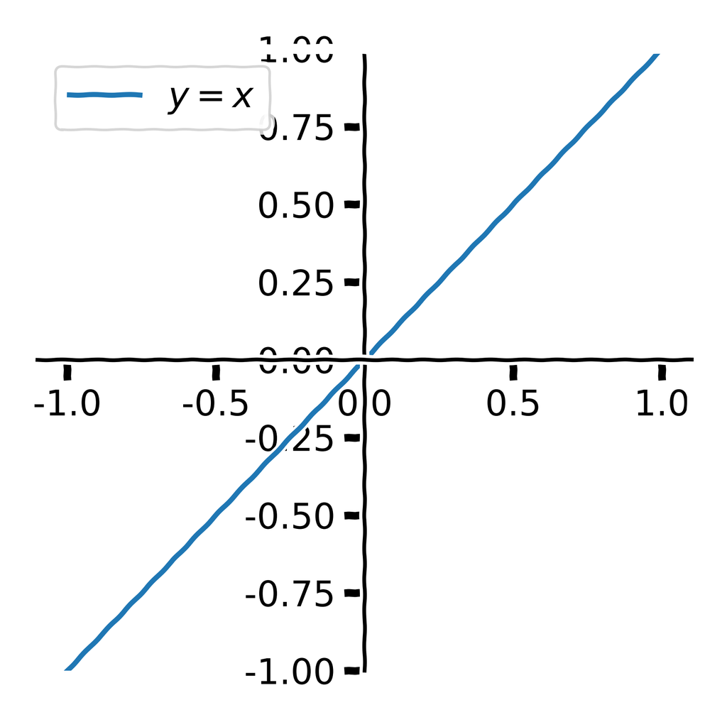

- What is the direction of *steepest descent?*

$$-\frac{dy}{dx}$$

## Fitting a straight line with SGD III

- To fit a function, we essentially want to create a model which describes data.
- We therefore need a way of measuring how a model’s predictions deviate from our observations.
- Consider the data:

| $x_{i}$ | $y_{i}$ |
| --- | --- |
| 1.0 | 2.1 |
| 2.0 | 3.9 |
| 3.0 | 6.2 |

- We can measure the distance between $f(x_{i})$ and $y_{i}$.
- Normally we might consider the mean-squared error:

$$L_{\text{MSE}} = \frac{1}{n}\sum_{i=1}^{n}\left(y_{i} - f(x_{i})\right)^{2}$$

- We can differentiate the loss function w.r.t. to each parameter in the the model $f$.
- We can use the direction of steepest descent to iteratively ‘nudge’ the parameters in a direction which reduces the loss.

## Fitting a straight line with SGD IV

$$L_{\text{MSE}} = \frac{1}{n}\sum_{i=1}^{n}(y_{i} - f(x_{i}))^{2}\\
= \frac{1}{n}\sum_{i=1}^{n}(y_{i} - mx_{i} + c)^{2}$$

- We can iteratively minimise the loss by stepping the model’s parameters in the direction of steepest descent:

$$m_{n + 1} = -m_{n}\frac{dL}{dm} \cdot l_{r}$$

$$c_{n + 1} = -c_{n}\frac{dL}{dm} \cdot l_{r}$$

- $l_{\text{r}}$ is a small constant known as the *learning rate*.

## Quick recap

To fit a model we need:

- A model.
- Some data.
- A loss function
- An optimisation procedure (often SGD and other flavours of SGD).

All in all, ’tis quite simple.

## What about neural networks?

- Neural networks are just functions.
- We can ‘’train’’, or fit, them as we would any other function:
  - by iteratively nudging parameters to minimise a the loss.
- With neural networks, differentiating the loss function is a bit more complicated.
  - but ultimately it’s just the chain rule.
- We won’t go through any more maths on the matter—learning resources on the topic are in no short supply.

## Fully-connected neural networks

- The simplest neural networks commonly used are generally called fully-connected nerual nets, dense networks, multi-layer perceptrons or artifical neural networks (ANNs).
- We map between the features at consecutive layers through matrix multiplication and the application of some non-linear activation function.

$$a_{l+1} = \sigma \left( W_{l}a_{l} + b_{l} \right)$$

- For common choices of activation functions, see the [PyTorch](https://pytorch.org/docs/stable/nn.html#non-linear-activations-weighted-sum-nonlinearity) docs.

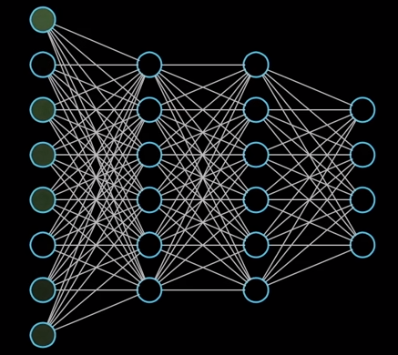

## Uses: Classification and Regression

- Fully-connected neural networks are often applied to tabular data.
  - I.e. where it makes sense to express the data in table-like object (such as a data frame).
  - The inputs features, and targets, are presented as vectors.
- Normally people use neural networks for one of two things:
  - Classification: assigning a semantic label to something—i.e. is this a dog or cat?
  - Regression: Estimating a continuous quantity such as mass or volume.

# Python and PyTorch

- In this workship-lecture-thing, we will implement some straightforward neural networks in PyTorch, and use them for different classification and regression problems.
- PyTorch is a deep learning framework that can be used in both Python and C++.
  - I have never met anyone actually training models in C++; I find it a bit weird.
- See the PyTorch website: https://pytorch.org/

# Exercises: Penguins

[figure not shown]

## Exercise 1—classification

- In this exercise, you will train a fully-connected neural network to classify the species of penguins based on certain physical features.
- https://github.com/allisonhorst/palmerpenguins
- Thanks to Jack Atkinson for suggesting this dataset.

## Exercise 2—regression

- In this exercise, you will train a fully-connected neural network to predict the mass of penguins based on other physical features.
- https://github.com/allisonhorst/palmerpenguins
- Thanks (again) to Jack Atkinson for suggesting this dataset.

# Part 2: Fun with CNNs

# Further information

## Slides

## Contact

## Resources

[figure not shown]